# Traffic_Sign_Classifier

## Building a Traffic Sign Recognition Classifier

## Step 0: Load The Data

The pickled data is a dictionary with 4 key/value pairs:

- `'features'` is a 4D array containing raw pixel data of the traffic sign images, (num examples, width, height, channels).
- `'labels'` is a 1D array containing the label/class id of the traffic sign. The file `signnames.csv` contains id -> name mappings for each id.
- `'sizes'` is a list containing tuples, (width, height) representing the original width and height the image.
- `'coords'` is a list containing tuples, (x1, y1, x2, y2) representing coordinates of a bounding box around the sign in the image. **THESE COORDINATES ASSUME THE ORIGINAL IMAGE. THE PICKLED DATA CONTAINS RESIZED VERSIONS (32 by 32) OF THESE IMAGES**

```python
# Load pickled data
import pickle

# Loading the training and testing data

training_file = "./data/train.p"
validation_file= "./data/valid.p"
testing_file = "./data/test.p"

with open(training_file, mode='rb') as f:
    train = pickle.load(f)
with open(validation_file, mode='rb') as f:
    valid = pickle.load(f)
with open(testing_file, mode='rb') as f:
    test = pickle.load(f)

X_train, y_train = train['features'], train['labels']
X_TRAIN, y_TRAIN = train['features'], train['labels']
X_valid, y_valid = valid['features'], valid['labels']
X_test, y_test = test['features'], test['labels']
```

```python
X_train[1].shape
```

```
(32, 32, 3)
```

## Step 1: Dataset Summary & Exploration

I have used numpy to calculate a basic summary of the dataset.

```python
### Replace each question mark with the appropriate value.
### Use python, pandas or numpy methods rather than hard coding the results

# Number of training examples
n_train = X_train.shape[0]

# Number of validation examples
n_validation = X_valid.shape[0]

# Number of testing examples.
n_test = X_test.shape[0]

# What's the shape of a traffic sign image
image_shape = X_train[0].shape

# How many unique classes/labels there are in the dataset.
import pandas as pd
classIDs = pd.read_csv('./signnames.csv')
n_classes = classIDs.shape[0]

print("Number of training examples =", n_train)
print("Number of validation examples = ", n_validation)
print("Number of testing examples =", n_test)
print("Image data shape =", image_shape)
print("Number of classes =", n_classes)
```

```
Number of training examples = 34799
Number of validation examples =  4410
Number of testing examples = 12630
Image data shape = (32, 32, 3)
Number of classes = 43
```

### An exploratory visualization of the dataset

I mainly use [Matplotlib](http://matplotlib.org/) to visualize the German Traffic Signs Dataset using the pickled file(s). **NOTE:** It's recommended you start with something simple first. If you wish to do more, come back to it after you've completed the rest of the sections. It can be interesting to look at the distribution of classes in the training, validation and test set. Is the distribution the same? Are there more examples of some classes than others?

```python
import tensorflow as tf
import numpy as np
### Data exploration visualization code goes here.
import matplotlib.pyplot as plt
# Visualizations will be shown in the notebook.
%matplotlib inline
```

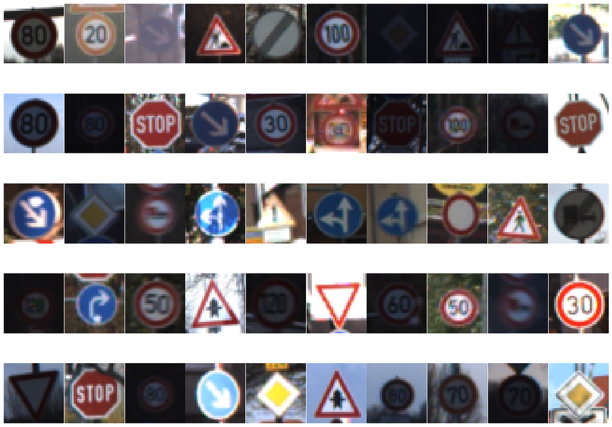

```python
# Visualize some random selection of the data
import random
nrows = 5
ncols = 10
fig, axes = plt.subplots(nrows, ncols, figsize=(20,15))
fig.subplots_adjust(hspace=0.1, wspace=0.01)
indices = random.sample(range(0,n_train), nrows*ncols)
for i, index in enumerate(indices):
    axes[i//ncols][i - (i//ncols)*ncols].imshow(X_train[index])
    axes[i//ncols][i - (i//ncols)*ncols].axis('off')
```

```python
# Visualizing the distribution of the classes
def dist_plot(y):
    height = [len(np.where(y==i)[0]) for i in range(n_classes)]
    plt.bar(range(n_classes), height)
    return
```

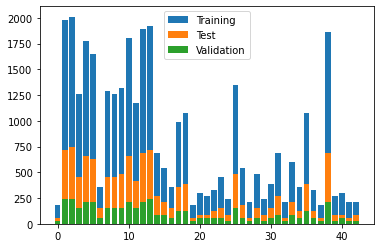

```python
dist_plot(y_train)
dist_plot(y_test)
dist_plot(y_valid)
plt.legend(['Training','Test', 'Validation'])
```

## Step 2: Designing and Testing a Model Architecture

Here I design and implement a deep learning model that learns to recognize traffic signs. I will train and test my model on the [German Traffic Sign Dataset](http://benchmark.ini.rub.de/?section=gtsrb&subsection=dataset).

The implemention would be similar to what is outlined in this [article](http://yann.lecun.com/exdb/publis/pdf/sermanet-ijcnn-11.pdf).

There are various aspects to consider when thinking about this problem:

- Neural network architecture (is the network over or underfitting?)
- Play around preprocessing techniques (normalization, rgb to grayscale, etc)
- Number of examples per label (some have more than others).

### Pre-process the Data Set (normalization, grayscale, etc.)

As a first step, I convert the images to grayscale. Minimally, the image data should be normalized so that the data has mean zero and equal variance. For image data, `(pixel - 128)/ 128` is a quick way to approximately normalize the data which I have used in this project.

```python
def rgb2gray(batch):
    return np.reshape(np.dot(batch[...,:3], [0.2989, 0.5870, 0.1140]), (-1,32,32,1))
```

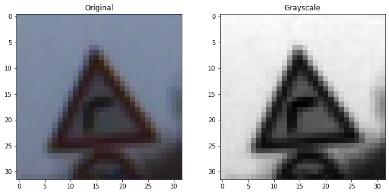

```python
fig, axes = plt.subplots(1,2, figsize=(11,5))
idx = random.randint(0,n_train)
axes[0].imshow(X_train[idx])
axes[0].set_title('Original')
axes[1].imshow(rgb2gray(X_train[idx])[0], cmap='gray')
axes[1].set_title('Grayscale')
```

```python
def preprocess(batch):
    batch_out = rgb2gray(batch)
    batch_out = (batch_out-128)/128
    return np.float32(batch_out)
```

```python
### Preprocess the data here. It is required to normalize the data. Other preprocessing steps could include
### converting to grayscale, etc.
X_train_pre = preprocess(X_train)
X_valid_pre = preprocess(X_valid)
X_test_pre = preprocess(X_test)

from sklearn.utils import shuffle
```

### Model Architecture

```python
### Define your architecture here.
```

```python
# Some Hyper-parameters
EPOCHS = 25
BATCH_SIZE = 256
RATE = 0.001
```

```python
def NeuNet_v2(x):
    # Arguments used for tf.truncated_normal, randomly defines variables for the weights and biases for each layer
    mu = 0
    sigma = 0.1
    weights = {'lay1':tf.Variable(tf.truncated_normal([5,5,1,6], mean = mu, stddev = sigma), dtype=tf.float32),
               'lay2':tf.Variable(tf.truncated_normal([5,5,6,16], mean = mu, stddev = sigma), dtype=tf.float32),
               'lay3':tf.Variable(tf.truncated_normal([5,5,16,400], mean = mu, stddev = sigma), dtype=tf.float32),
               'lay4':tf.Variable(tf.truncated_normal([800,200], mean = mu, stddev = sigma), dtype=tf.float32),
               'lay5':tf.Variable(tf.truncated_normal([200,n_classes], mean = mu, stddev = sigma), dtype=tf.float32)}
    biases = {'lay1':tf.Variable(tf.truncated_normal([6], mean = mu, stddev = sigma), dtype=tf.float32),
              'lay2':tf.Variable(tf.truncated_normal([16], mean = mu, stddev = sigma), dtype=tf.float32),
              'lay3':tf.Variable(tf.truncated_normal([400], mean = mu, stddev = sigma), dtype=tf.float32),
              'lay4':tf.Variable(tf.truncated_normal([200], mean = mu, stddev = sigma), dtype=tf.float32),
              'lay5':tf.Variable(tf.truncated_normal([n_classes], mean = mu, stddev = sigma), dtype=tf.float32)}

    # Layer 1: Convolutional. Input = 32x32x1. Output = 28x28x6.
    x = tf.nn.conv2d(x, filters=weights['lay1'], strides=[1,1,1,1], padding='VALID')
    x = tf.nn.bias_add(x, biases['lay1'])
    # Activation.
    x = tf.nn.relu(x)
    # Pooling. Input = 28x28x6. Output = 14x14x6.
    x = tf.nn.avg_pool(x, ksize=[1,2,2,1], strides=[1,2,2,1], padding='SAME')
    # Layer 2: Convolutional. Output = 10x10x16.
    x = tf.nn.conv2d(x, filters=weights['lay2'], strides=[1,1,1,1], padding='VALID')
    x = tf.nn.bias_add(x, biases['lay2'])
    # Activation.
    x = tf.nn.relu(x)
    # Pooling. Input = 10x10x16. Output = 5x5x16.
    x = tf.nn.avg_pool(x, ksize=[1,2,2,1], strides=[1,2,2,1], padding='SAME')
    # Flatten. Input = 5x5x16. Output = 400.
    lay2_flat = tf.compat.v1.layers.flatten(x)
    # Layer 3: Convolutional. Input = 5x5x16. Output = 1x1x400
    x = tf.nn.conv2d(x, filters=weights['lay3'], strides=[1,1,1,1], padding='VALID')
    x = tf.nn.bias_add(x, biases['lay3'])
    # Activation.
    x = tf.nn.relu(x)
    # Flatten. Input = 1x1x400. Output = 400.
    lay3_flat = tf.compat.v1.layers.flatten(x)
    # Concatenation
    x = tf.concat([lay3_flat, lay2_flat], 1)
    # Dropout
    x = tf.nn.dropout(x, keep_prob)
    # Layer 4: Fully Connected. Input = 800. Output = 200.
    x = tf.matmul(x, weights['lay4'])
    x = tf.nn.bias_add(x, biases['lay4'])
    # Activation.
    x = tf.nn.relu(x)
    # Dropout
    x = tf.nn.dropout(x, keep_prob)
    # Layer 5: Fully Connected. Input = 200. Output = 43.
    x = tf.matmul(x, weights['lay5'])
    x = tf.nn.bias_add(x, biases['lay5'])

    logits = x

    return logits
```

### Train, Validate and Test the Model

A validation set can be used to assess how well the model is performing. A low accuracy on the training and validation sets imply underfitting. A high accuracy on the training set but low accuracy on the validation set implies overfitting.

```python
### Train your model here.
### Calculate and report the accuracy on the training and validation set.
### Once a final model architecture is selected,
### the accuracy on the test set should be calculated and reported as well.
### Feel free to use as many code cells as needed.
tf.reset_default_graph()

x = tf.placeholder(tf.float32, (None,32,32,1))
y = tf.placeholder(tf.int32, (None))
keep_prob = tf.placeholder(tf.float32)
one_hot_y = tf.one_hot(y, n_classes)
```

```python
logits = NeuNet_v2(x)
cross_entropy = tf.nn.softmax_cross_entropy_with_logits_v2(labels=one_hot_y, logits=logits)
loss_operation = tf.reduce_mean(cross_entropy)
optimizer = tf.train.AdamOptimizer(learning_rate=RATE)
training_operation = optimizer.minimize(loss_operation)
```

[output not shown]

```python
correct_prediction = tf.equal(tf.argmax(logits, 1), tf.argmax(one_hot_y, 1))
accuracy_operation = tf.reduce_mean(tf.cast(correct_prediction, tf.float32))
saver = tf.train.Saver()

def evaluate(X_data, y_data):
    num_examples = len(X_data)
    total_accuracy = 0
    sess = tf.get_default_session()
    for offset in range(0, num_examples, BATCH_SIZE):
        batch_x, batch_y = X_data[offset:offset+BATCH_SIZE], y_data[offset:offset+BATCH_SIZE]
        accuracy = sess.run(accuracy_operation, feed_dict={x: batch_x, y: batch_y, keep_prob: 1.0})
        total_accuracy += (accuracy * len(batch_x))
    return total_accuracy/num_examples
```

```python
with tf.Session() as sess:
    sess.run(tf.global_variables_initializer())
    print("Training...")
    print()
    for i in range(EPOCHS):
        X_train_pre, y_train = shuffle(X_train_pre, y_train)
        for offset in range(0, n_train, BATCH_SIZE):
            end = offset + BATCH_SIZE
            batch_x, batch_y = X_train_pre[offset:end], y_train[offset:end]
            sess.run(training_operation, feed_dict={x: batch_x, y: batch_y, keep_prob: 0.5})

        validation_accuracy = evaluate(X_valid_pre, y_valid)
        print("EPOCH {} ...".format(i+1))
        print("Validation Accuracy = {:.3f}".format(validation_accuracy))
        print()

    saver.save(sess, './NeuNet')
    print("Model saved")
```

```
Training...

EPOCH 1 ...
Validation Accuracy = 0.603

EPOCH 2 ...
Validation Accuracy = 0.793

EPOCH 3 ...
Validation Accuracy = 0.846

EPOCH 4 ...
Validation Accuracy = 0.873

EPOCH 5 ...
Validation Accuracy = 0.886

EPOCH 6 ...
Validation Accuracy = 0.908

EPOCH 7 ...
Validation Accuracy = 0.900

EPOCH 8 ...
Validation Accuracy = 0.921

EPOCH 9 ...
Validation Accuracy = 0.928

EPOCH 10 ...
Validation Accuracy = 0.919

EPOCH 11 ...
Validation Accuracy = 0.934

EPOCH 12 ...
Validation Accuracy = 0.936

EPOCH 13 ...
Validation Accuracy = 0.941
```

[output cut: 23 more lines]

```
Validation Accuracy = 0.954

EPOCH 22 ...
Validation Accuracy = 0.949

EPOCH 23 ...
Validation Accuracy = 0.946

EPOCH 24 ...
Validation Accuracy = 0.951

EPOCH 25 ...
Validation Accuracy = 0.957

Model saved
```

```python
## Testing on the Test set
with tf.Session() as sess:
    init = tf.global_variables_initializer()
    sess.run(init)
    saver2 = tf.train.import_meta_graph('./NeuNet.meta')
    saver2.restore(sess, './NeuNet')
    train_accuracy = evaluate(X_train_pre, y_train)
    print("Training Accuracy = {:.3f}".format(train_accuracy))
    print()
    valid_accuracy = evaluate(X_valid_pre, y_valid)
    print("Validation Accuracy = {:.3f}".format(valid_accuracy))
    print()
    test_accuracy = evaluate(X_test_pre, y_test)
    print("Test Accuracy = {:.3f}".format(test_accuracy))
    print()
```

```
INFO:tensorflow:Restoring parameters from ./NeuNet
Training Accuracy = 0.998

Validation Accuracy = 0.957

Test Accuracy = 0.943
```

## Step 3: Test a Model on New Images

I further test the trained model on 5 new traffic sign images that I got from the Internet.

### Load and Output the Images

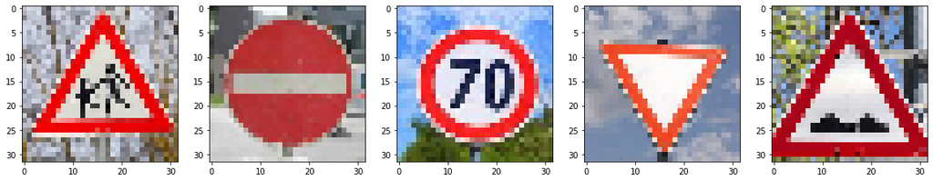

```python
### Load the images and plot them here.
import glob
import cv2
web_images = glob.glob('./web_examples/*.png')
fig, axes = plt.subplots(1,5, figsize=(20,4))
X_web = []
for i, p in enumerate(web_images):
    img = plt.imread(p)
    img = img[...,:3]
    img = cv2.resize(img, (32,32))
    X_web.append(img)
    axes[i].imshow(img)

X_web = np.uint8(255 * np.array(X_web))
y_web = np.int32([28, 17, 4, 13, 22])
```

### Predict the Sign Type for Each Image

```python
### Run the predictions here and use the model to output the prediction for each image.
### Make sure to pre-process the images with the same pre-processing pipeline used earlier.
X_web_pre = preprocess(X_web)
## Testing on the Web image set
with tf.Session() as sess:
    init = tf.global_variables_initializer()
    sess.run(init)
    saver2 = tf.train.import_meta_graph('./NeuNet.meta')
    saver2.restore(sess, './NeuNet')
    y_web_nn = sess.run(logits, feed_dict={x: X_web_pre, keep_prob: 1.0})
    print(sess.run(tf.argmax(y_web_nn, 1)))
    #web_accuracy = evaluate(X_web_pre, y_test)
    #print("Validation Accuracy = {:.3f}".format(test_accuracy))
    #print()
```

```
INFO:tensorflow:Restoring parameters from ./NeuNet
[28 17  4 13 22]
```

### Analyze Performance

```python
### Calculate the accuracy for these 5 new images.
### For example, if the model predicted 1 out of 5 signs correctly, it's 20% accurate on these new images.
web_accuracy = tf.reduce_mean(tf.cast(tf.equal(tf.argmax(y_web_nn, axis=1), y_web), tf.float32))
with tf.Session() as sess:
    print('Accuracy for web images is {} %'.format(sess.run(web_accuracy)*100))
```

```
Accuracy for web images is 100.0 %
```

### Top 5 Softmax Probabilities

For each of the new images, I have printed out the model's softmax probabilities to show the **certainty** of the model's predictions. I have used `tf.nn.top_k` to pick the top 5 probabilities and plotted them in logscale.

```python
# Getting the IDs and the name of the signs
IDs = classIDs['ClassId'].tolist()
Names = classIDs['SignName'].tolist()
```

```
INFO:tensorflow:Restoring parameters from ./NeuNet
[[9.88904536e-01 1.10941594e-02 1.17252659e-06 1.15816185e-07
  2.85304775e-08]]
INFO:tensorflow:Restoring parameters from ./NeuNet
[[1.0000000e+00 2.7578189e-12 5.3416077e-13 8.5029714e-14 3.0566793e-14]]
INFO:tensorflow:Restoring parameters from ./NeuNet
[[9.9993610e-01 6.3867861e-05 2.0934992e-08 5.9435346e-11 2.6303664e-13]]
INFO:tensorflow:Restoring parameters from ./NeuNet
[[1.0000000e+00 4.3957307e-13 4.5141286e-14 3.4279296e-15 2.1896223e-16]]
INFO:tensorflow:Restoring parameters from ./NeuNet
[[8.2762367e-01 1.7237638e-01 4.7686224e-09 1.6203485e-09 3.0880803e-10]]
```

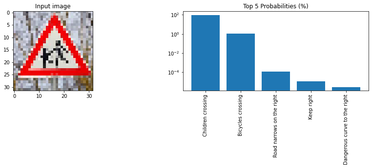

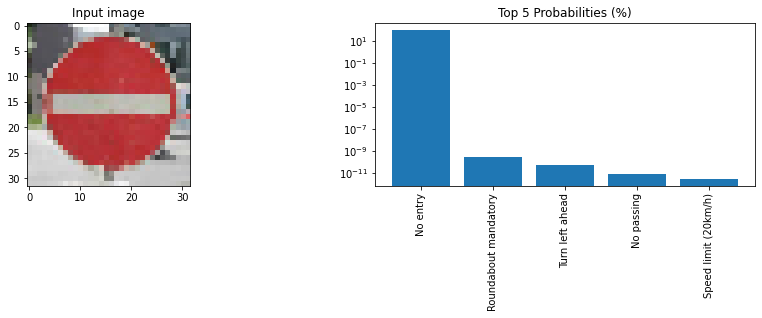

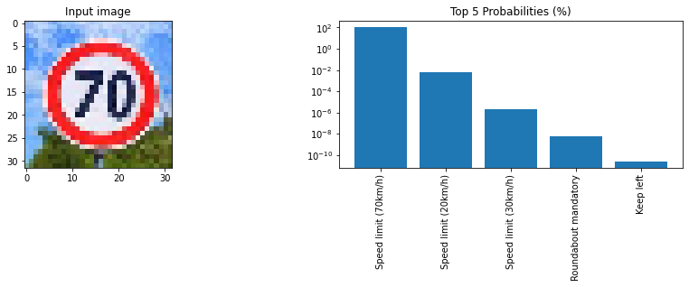

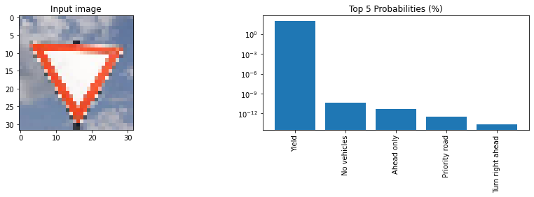

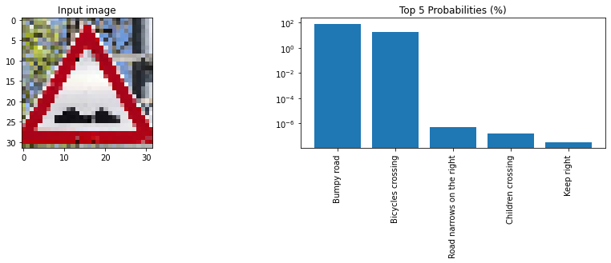

```python
### Print out the top five softmax probabilities for the predictions on the German traffic sign images found on the web.
for i, img in enumerate(X_web_pre):
    img = img.reshape([1,32,32,1])
    with tf.Session() as sess:
        init = tf.global_variables_initializer()
        sess.run(init)
        saver2 = tf.train.import_meta_graph('./NeuNet.meta')
        saver2.restore(sess, './NeuNet')
        logits_5 = sess.run(tf.nn.top_k(tf.nn.softmax(logits), k=5), feed_dict={x: img, keep_prob: 1.0})
    print(logits_5.values)
    fig, axes = plt.subplots(1,2, figsize=[15,3])
    axes[0].imshow(X_web[i])
    axes[0].set_title('Input image')
    axes[1].bar(np.arange(len(logits_5.indices[0])), 100*logits_5.values[0])
    axes[1].set_yscale('log')
    axes[1].set_title('Top 5 Probabilities (%)')
    axes[1].set_xticks(np.arange(len(logits_5.indices[0])))
    labels = [Names[x] for x in [IDs.index(x) for x in logits_5.indices[0]]]
    axes[1].set_xticklabels(labels, rotation=90)
```